# Mortality Time Series with the CenSoc-Numident Dataset

Leslie Root (leslie.root@berkeley.edu)

2020-09-16

**Summary**: This vignette gives an overview of the CenSoc-Numident dataset. In the examples that follow, we use the Numident data in an *unlinked* format. Our goals for this vignette are:

```
1. To develop familiarity with the Numident death data, its possibilities and limitations;
2. To construct and visualize a descriptive analysis of seasonal death patterns using this data; and
3. To consider possible avenues for extending this analysis with a linked dataset.
```

The original R notebook (.Rmd file) for this vignette can be downloaded [here](https://github.com/lesliejroot/CenSoc).

Before getting started with the vignette, make sure to:

- [Download](https://censoc-download.demog.berkeley.edu/) the CenSoc Numident File (note: not the demo file! The file used here is currently called censoc_numident_v1.zip)
- Install packages if necessary:  
  -tidyverse  
  -knitr  
  -here  
  -viridis

# Getting started

Load packages and read in the data:

```r
## Library Packages
library(tidyverse)
library(knitr)
library(here)
library(viridis)
library(kableExtra)

#edit this line to make sure it points to your downloaded dataset. I like to use the "here" package to make finding files easier, but if you prefer not to, you can remove it from this command. The file is large, so this might take a few seconds to run.
options(readr.show_progress = FALSE)
num <- read_csv(here("/censoc_numident_v1.csv"))

## what are our variables?
colnames(num)
```

```
##  [1] "HISTID"                "byear"                 "bmonth"
##  [4] "dyear"                 "dmonth"                "death_age"
##  [7] "sex"                   "race_first"            "race_first_cyear"
## [10] "race_first_cmonth"     "race_last"             "race_last_cyear"
## [13] "race_last_cmonth"      "bpl"                   "zip_residence"
## [16] "socstate"              "age_first_application" "weight"
```

We can see from the list of variable names that we have a pretty limited amount of information:  
- person ID (used to link to the 1940 Census)  
- birth and death dates (month and year)  
- age at death  
- sex  
- a few measures of race, with information on when they were collected  
- birthplace  
- residence at time of death (as a ZIP code)  
- state where the Social Security card was issued  
- age at first Social Security application  
- and a person-weight.

*Note that this is more information than the CenSoc-DMF data, which does not contain Social Security application covariates, and only includes men. (However, the DMF data has more years available.) For comparison of the various datasets currently available, be sure to visit [CenSoc](http://censoc.berkeley.edu).

Anything else we want to know about the people whose deaths are recorded in this dataset will have to come from linkage to the 1940 Census. For this vignette, though, let's see what we can get out of the data we have here. First, since this dataset contains microdata on deaths, let's see what kind of deaths we're looking at.

```r
table(num$death_age)
```

```
##
##     47     48     49     50     51     52     53     54     55     56     57
##     27    699   1718   3033   4648   7091  10489  14605  19522  25986  32195
##     58     59     60     61     62     63     64     65     66     67     68
##  40148  48789  60388  72899 109996 130914 153436 180615 195611 208274 219115
##     69     70     71     72     73     74     75     76     77     78     79
## 231426 243118 254964 266056 275551 280266 283916 284096 280353 276115 267358
##     80     81     82     83     84     85     86     87     88     89     90
## 259530 247181 233436 219060 201134 182838 163871 144741 126266 106831  88080
##     91     92     93     94     95     96     97     98     99    100    101
##  72039  59986  49889  41331  34733  28111  22213  17408  13087   9750   6985
##    102    103    104    105    106    107    108    109    110    111    112
##   4538   2995   1921   1125    698    390    214    116     54     27     16
##    113    114    115    116    118    120    121
##     10      5      5      1      1      2      1
```

Interesting - our death ages start at 47 and go up to 121. Why is that? Let's look by year of death:

```r
head(table(num$death_age,num$dyear),10)
```

```
##
##      1988 1989 1990 1991 1992 1993 1994 1995 1996 1997 1998 1999 2000 2001 2002
##   47   27    0    0    0    0    0    0    0    0    0    0    0    0    0    0
##   48  661   38    0    0    0    0    0    0    0    0    0    0    0    0    0
##   49  971  717   30    0    0    0    0    0    0    0    0    0    0    0    0
##   50 1013 1118  856   46    0    0    0    0    0    0    0    0    0    0    0
##   51 1113 1145 1298 1039   53    0    0    0    0    0    0    0    0    0    0
##   52 1271 1288 1349 1558 1545   80    0    0    0    0    0    0    0    0    0
##   53 1467 1481 1407 1676 2283 2061  114    0    0    0    0    0    0    0    0
##   54 1564 1639 1639 1859 2425 2946 2413  120    0    0    0    0    0    0    0
##   55 1723 1765 1936 1948 2608 3246 3408 2763  125    0    0    0    0    0    0
##   56 1993 1933 2075 2313 2904 3556 3690 4200 3176  146    0    0    0    0    0
##
##      2003 2004 2005
##   47    0    0    0
##   48    0    0    0
##   49    0    0    0
##   50    0    0    0
##   51    0    0    0
##   52    0    0    0
##   53    0    0    0
##   54    0    0    0
##   55    0    0    0
##   56    0    0    0
```

Aha! It's because our data runs from 1988 to 2005 - the years with the best Social Security death coverage. And we only observe people who were alive in 1940 and can be linked to the 1940 Census.

# Mortality time series by sex

Let's construct a straightforward count of Numident deaths by month/year, broken down by sex. We will need to adjust the Numident data using the person weights provided. These weights were calculated based on [Human Mortality Database](http://mortality.org) data - for more details, see the [CenSoc Methods Protocol (pdf)](https://censoc.berkeley.edu/wp-content/uploads/2020/04/censoc_methods_protocol.pdf) - and it's very important to use them, as some of them are quite large!

This means we will restrict ages at death and years of data to keep only those observations with person-weights assigned. Person-weights were assigned to those who were born 1895-1939 and died aged 65-100. Here we will restrict a bit further and look only at deaths aged 65-95, so we can include more years of data (such that everyone in the data was born in 1895 or after).

Restricting the data and transforming it into a monthly sex-specific count of deaths:

```r
deaths <- num %>%
  filter(death_age %in% (65:95) & dyear %in% (1991:2004)) %>%
  #"mutate" sex to something more intuitive
  mutate(sex = ifelse(sex==1, "M", "F")) %>%
  #to plot a timeseries, let's make the dates into an index. January 1988 becomes 1988.0, and each month adds 1/12 (~0.083) to that number.
  #here we see that we can use "mutate" not only to change the coding of extant variables, but to create a new variable, "index":
  mutate(index = (dyear + (dmonth/12-1/12))) %>%
  #might as well keep year and month data, as well as index (it doesn't add any information, but later we'll use the dyear column again). group_by helps us transform our dataframe from microdata into summary counts:
  group_by(dyear,dmonth,index,sex) %>%
  #final step - make a new variable that counts the number of deaths by the variables specified in the above step^
  summarize(deaths=sum(weight))

head(deaths)
```

| dyear | dmonth | index | sex | deaths |
| --- | --- | --- | --- | --- |
| 1991 | 1 | 1991.000 | F | 69369.98 |
| 1991 | 1 | 1991.000 | M | 61190.16 |
| 1991 | 2 | 1991.083 | F | 64440.03 |
| 1991 | 2 | 1991.083 | M | 58170.19 |
| 1991 | 3 | 1991.167 | F | 70861.25 |
| 1991 | 3 | 1991.167 | M | 61890.10 |

Plotting the monthly deaths:

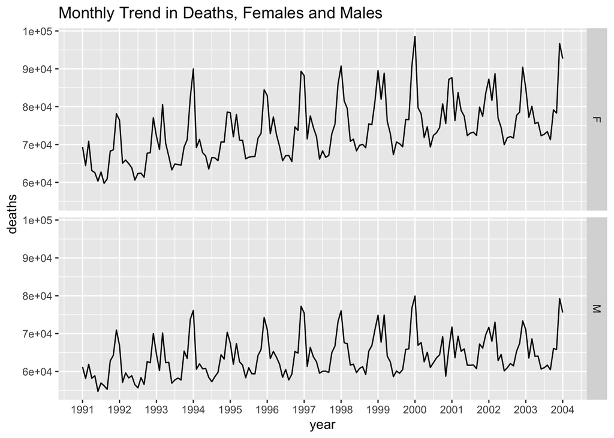

```r
deaths %>%
  ggplot(aes(index, deaths)) +
  geom_line() +
  ylab("deaths")+
  xlab("year")+
  scale_x_continuous(breaks = seq(1991, 2004, 1),lim=c(1991,2004))+
  facet_grid(rows=vars(sex))+
  ggtitle("Monthly Trend in Deaths, Females and Males")
```

These plots show that deaths oscillate throughout the year, and it looks like they do so in somewhat regular fashion. Let's investigate further.

## Isolating seasonal variation

We can divide the observed deaths each month by the expected deaths to get a standardized version of the seasonal variation - we will no longer see the rising time trend in deaths, only the fluctuations throughout each year. Monthly expected deaths are defined as:

$$monthly\_expected\_deaths = \frac{yearly\_deaths}{days\_in\_year} * days\_in\_month$$

If we use a standard January-December year, this equation's accuracy is contingent on the overall mortality trend being relatively flat. Instead, this code uses a moving average, conceiving of each "year" as deaths in the 12-month period surrounding the month in question. (For example, the "yearly deaths" for March 1997 would be the deaths in the months of October 1996 through September 1997, with March 1997 in the center.) This assumes a roughly linear trend in overall deaths, rather than a flat trend.

I then calculated "death variation" as a percentage deviation from the monthly expectation, but there are certainly other substantively identical ways one could construct this variable, if this construction doesn't seem intuitive to you:

$$death\_variation = (100 * \frac{monthly\_observed\_deaths}{monthly\_expected\_deaths})-100$$

```r
deathsf <- deaths %>%
  filter(sex=="F")

#generate moving sum of yearly deaths
for (i in 6:(nrow(deathsf)-6)) {
  deathsf[i,6] <- sum(deathsf[(c((i-5):(i+6))),5])
}

names(deathsf)[6]<- "total"

deathsf$expected <- ifelse(deathsf$dmonth %in% c(4,6,9,11),30/365*deathsf$total,NA)
deathsf$expected <- ifelse(deathsf$dmonth %in% c(1,3,5,7,8,10,12),31/365*deathsf$total,deathsf$expected)
deathsf$expected <- ifelse(deathsf$dmonth == 2,28/365*deathsf$total,deathsf$expected)
deathsf$expected <- ifelse(deathsf$dmonth == 2 & deathsf$dyear %in% c(1992,1996,
                                                              2000,2004),29/366*deathsf$total,deathsf$expected)
deathsf$expected <- ifelse(deathsf$dmonth %in% c(4,6) & deathsf$dyear %in% c(1992,1996,
                                                                     2000,2004),30/366*deathsf$total,deathsf$expected)
deathsf$expected <- ifelse(deathsf$dmonth %in% c(3,5,7) & deathsf$dyear %in% c(1992,1996,
                                                                     2000,2004),31/366*deathsf$total,deathsf$expected)
deathsf$expected <- ifelse(deathsf$dmonth %in% c(9,11) & deathsf$dyear %in% c(1991,1995,
                                                                     1999,2003),30/366*deathsf$total,deathsf$expected)
deathsf$expected <- ifelse(deathsf$dmonth %in% c(8,10,12,1) & deathsf$dyear %in% c(1991,1995,
                                                                     1999,2003),31/366*deathsf$total,deathsf$expected)

deathsf$variation <- deathsf$deaths/deathsf$expected*100-100

#same for men
deathsm <- deaths %>%
  filter(sex=="M")

for (i in 6:(nrow(deathsm)-6)) {
  deathsm[i,6] <- sum(deathsm[(c((i-5):(i+6))),5])
}

names(deathsm)[6]<- "total"

deathsm$expected <- ifelse(deathsm$dmonth %in% c(4,6,9,11),30/365*deathsm$total,NA)
deathsm$expected <- ifelse(deathsm$dmonth %in% c(1,3,5,7,8,10,12),31/365*deathsm$total,deathsm$expected)
deathsm$expected <- ifelse(deathsm$dmonth == 2,28/365*deathsm$total,deathsm$expected)
deathsm$expected <- ifelse(deathsm$dmonth == 2 & deathsm$dyear %in% c(1992,1996,
                                                              2000,2004),29/366*deathsm$total,deathsm$expected)
deathsm$expected <- ifelse(deathsm$dmonth %in% c(4,6) & deathsm$dyear %in% c(1992,1996,
                                                                     2000,2004),30/366*deathsm$total,deathsm$expected)
deathsm$expected <- ifelse(deathsm$dmonth %in% c(3,5,7) & deathsm$dyear %in% c(1992,1996,
                                                                     2000,2004),31/366*deathsm$total,deathsm$expected)
deathsm$expected <- ifelse(deathsm$dmonth %in% c(9,11) & deathsm$dyear %in% c(1991,1995,
                                                                     1999,2003),30/366*deathsm$total,deathsm$expected)
deathsm$expected <- ifelse(deathsm$dmonth %in% c(8,10,12,1) & deathsm$dyear %in% c(1991,1995,
                                                                     1999,2003),31/366*deathsm$total,deathsm$expected)
deathsm$variation <- deathsm$deaths/deathsm$expected*100-100

deaths <- rbind(deathsf,deathsm)
```

Plotting the death variation with the secular time trend removed:

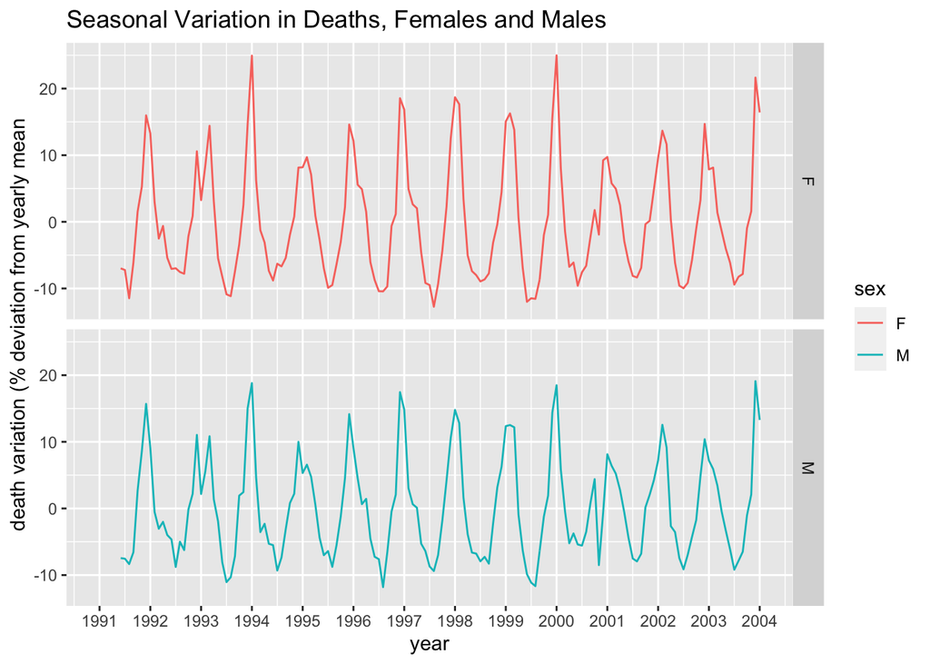

```r
deaths %>%
  ggplot(aes(index, variation,col=sex)) +
  geom_line()+
  ylab("death variation (% deviation from yearly mean")+
  xlab("year")+
  scale_x_continuous(breaks = seq(1991, 2004, 1),lim=c(1991,2004))+
  facet_grid(rows=vars(sex))+
  ggtitle("Seasonal Variation in Deaths, Females and Males")
```

Overlapping the two sexes makes it clearer that women experience more seasonal variation than men:

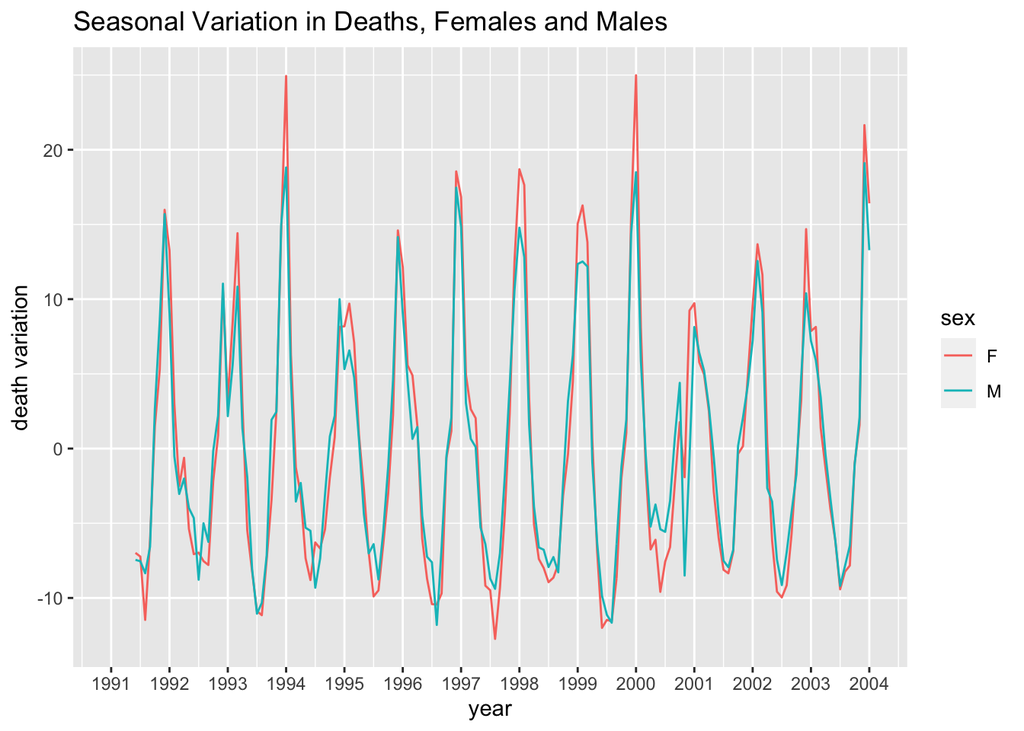

```r
deaths %>%
  ggplot(aes(index, variation,color=sex)) +
  geom_line()+
  ylab("death variation")+
    scale_x_continuous(breaks = seq(1991, 2004, 1),lim=c(1991,2004))+
  xlab("year")+
    ggtitle("Seasonal Variation in Deaths, Females and Males")
```

To get a clearer picture, let's directly compare the magnitude of female and male variation in death counts. This code gives us a measure of the difference in absolute value of female and male variation from the average - in other words, when women's death counts deviate more from their average than do men's from theirs, this index is positive. When men's death counts deviate more, it's negative. This figure is broken up into three graphs, so that we can see who deviates more from the average in the case of excess death, reduced death, and cases where one sex saw excess and the other saw reduced death in the same month.

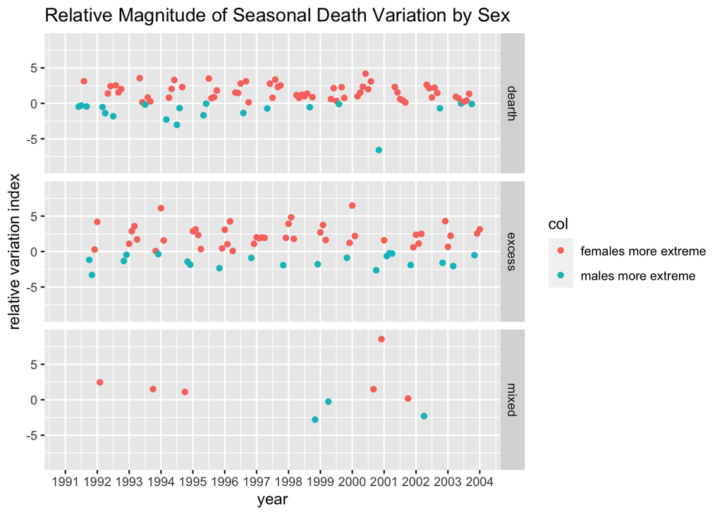

```r
deathsb <- merge(deathsf,deathsm,by="index")
deathsb <- deathsb %>%
  select(c(index,sex.x,variation.x,sex.y,variation.y)) %>%
  filter(!is.na(variation.x))

deathsb$diff <- abs(deathsb$variation.x)-abs(deathsb$variation.y)
deathsb$col <- ifelse(deathsb$diff >0,"females more extreme","males more extreme")
deathsb$type <- ifelse(deathsb$variation.x >0 & deathsb$variation.y > 0,"excess",NA)
deathsb$type <- ifelse(deathsb$variation.x <0 & deathsb$variation.y < 0,"dearth",deathsb$type)
deathsb$type <- ifelse(is.na(deathsb$type),"mixed",deathsb$type)


deathsb %>%
  ggplot(aes(index, diff,color=col)) +
  geom_point()+
  ylab("relative variation index")+
  xlab("year")+
  facet_grid(rows=vars(type))+
  scale_x_continuous(breaks = seq(1991, 2004, 1),lim=c(1991,2004))+
  ylim(c(-9,9))+
  ggtitle("Relative Magnitude of Seasonal Death Variation by Sex")
```

Why is the female variation consistently more extreme? One explanation could be sex differences in flu mortality: previous research shows higher female mortality from seasonal influenza. But let's look more closely at the distribution of male and female deaths. We'll do this like a population pyramid, but remember, without a denominator in this dataset, we're plotting the age distribution of *deaths*, not the age distribution of the population as a whole.

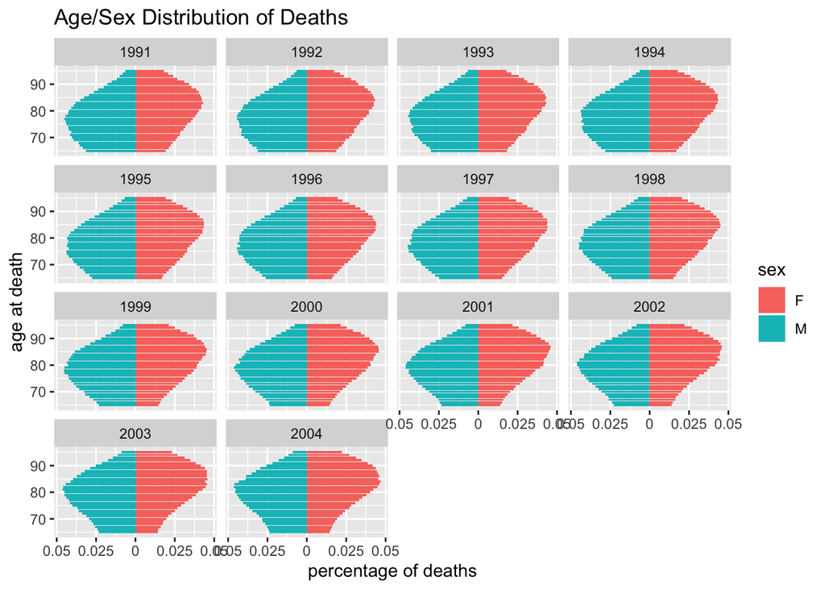

```r
hist <- num %>%
  filter(death_age %in% (65:95) & dyear %in% (1991:2004)) %>%
  mutate(sex = ifelse(sex==1, "M", "F"))

pyramid <- hist %>%
  group_by(death_age,sex,dyear) %>%
  summarize(deaths=sum(weight))

yrdeaths <- num %>%
  filter(death_age %in% (65:95) & dyear %in% (1991:2004)) %>%
  mutate(sex = ifelse(sex==1, "M", "F")) %>%
  group_by(dyear,sex) %>%
  summarize(deaths=sum(weight))

pyramid <- merge(pyramid,yrdeaths,by=c("sex","dyear"))
pyramid$percentage <- pyramid$deaths.x/pyramid$deaths.y

ggplot(pyramid, aes(x = death_age, fill = sex,
                 y = ifelse(sex == "M",
                            (-percentage),(percentage)))) +
  geom_bar(stat = "identity") +
  scale_y_continuous(labels = abs, limits = max(pyramid$percentage) * c(-1,1)) +
  xlab("age at death")+
  ylab("percentage of deaths")+
  coord_flip()+
  facet_wrap(vars(dyear))+
  ggtitle("Age/Sex Distribution of Deaths")
```

It looks like the female population has a consistently higher mean age at death than the male population. This probably contributes to females' more marked seasonal variation, since the older elderly are more likely to die from the flu.

# Seasonal death heatmaps

Finally, we can also plot the seasonal death patterns as a heatmap!

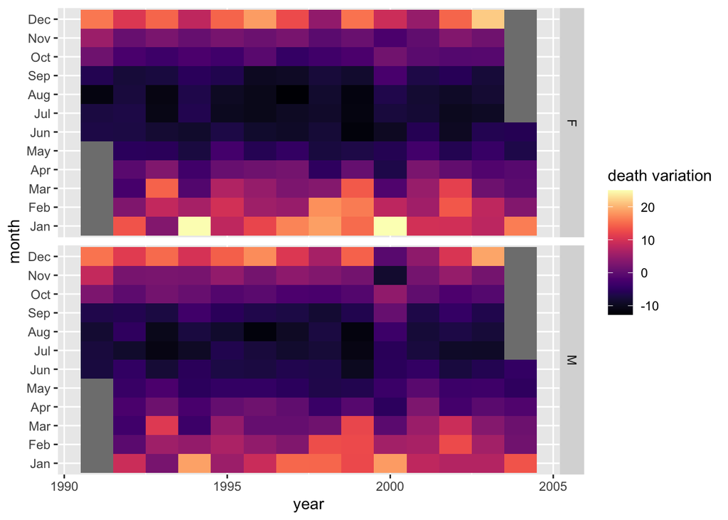

```r
deaths$dmonth_text <- as.factor(deaths$dmonth)

levels(deaths$dmonth_text) <- c("Jan","Feb","Mar","Apr","May","Jun","Jul","Aug","Sep","Oct","Nov","Dec")

ggplot(deaths, aes(dyear, dmonth_text, fill= variation)) +
  geom_tile() +
  scale_fill_viridis(option = "magma")+
  ylab("month")+
  xlab("year")+
  scale_color_discrete(name="death variation")+
  labs(fill = "death variation")+
  facet_grid(rows=vars(sex))
```

These heatmaps help us see clearly that June through September consistently have below-average deaths, while the month with the most excess death is generally between December and March. It also helps us visually identify unusual years - especially on the female plot, we can see that 1994 and 2000 had unusual death patterns, with very high deaths in January. We also see, on the male plot, unusually low deaths in November of 2000. The 1993-1994 and 1999-2000 flu seasons were unusually bad, which likely explains this pattern.

# Describing variation by age at death

Now that we see that women in this sample die at older ages than men, let's compare the amount of seasonal variation in death counts by both sex and age at death. First, we need to create a factor variable splitting the data into three age groups. Then we need to redo a good bit of the code above with this variable included.

```r
deaths2 <- num %>%
  filter(death_age %in% (65:95) & dyear %in% (1991:2004)) %>%
  #convert age into a factor with three levels: young, mid, and old
  mutate(age_index = ifelse(death_age<75,"young",NA))%>%
  mutate(age_index = ifelse(death_age>=75,"mid",age_index))%>%
  mutate(age_index = ifelse(death_age>=85,"old",age_index)) %>%
  mutate(sex = ifelse(sex==1, "M", "F")) %>%
  mutate(index = (dyear + (dmonth/12-1/12))) %>%
  group_by(dyear,dmonth, sex, index,age_index) %>%
  summarize(deaths=sum(weight))

#put the factor's levels in the proper order
deaths2$age_index <- factor(deaths2$age_index,levels=c("young","mid","old"))

deaths3 <- deaths2 %>%
  filter(sex == "M")

deaths2 <- deaths2 %>%
  filter(sex == "F")

###Reconstructing variation
##Women
#youngest old
deathsy <- deaths2 %>%
  filter(age_index=="young")


for (i in 6:(nrow(deathsy)-6)) {
  deathsy[i,7] <- sum(deathsy[(c((i-5):(i+6))),6])
}

names(deathsy)[7]<- "total"

deathsy$expected <- ifelse(deathsy$dmonth %in% c(4,6,9,11),30/365*deathsy$total,NA)
deathsy$expected <- ifelse(deathsy$dmonth %in% c(1,3,5,7,8,10,12),31/365*deathsy$total,deathsy$expected)
deathsy$expected <- ifelse(deathsy$dmonth == 2,28/365*deathsy$total,deathsy$expected)
deathsy$expected <- ifelse(deathsy$dmonth == 2 & deathsy$dyear %in% c(1988,1992,1996,
                                                              2000,2004),29/366*deathsy$total,deathsy$expected)
deathsy$expected <- ifelse(deathsy$dmonth %in% c(4,6) & deathsy$dyear %in% c(1988,1992,1996,
                                                                     2000,2004),30/366*deathsy$total,deathsy$expected)
deathsy$expected <- ifelse(deathsy$dmonth %in% c(3,5,7) & deathsy$dyear %in% c(1988,1992,1996,
                                                                     2000,2004),31/366*deathsy$total,deathsy$expected)
deathsy$expected <- ifelse(deathsy$dmonth %in% c(9,11) & deathsy$dyear %in% c(1991,1995,
                                                                     1999,2003),30/366*deathsy$total,deathsy$expected)
deathsy$expected <- ifelse(deathsy$dmonth %in% c(8,10,12,1) & deathsy$dyear %in% c(1991,1995,
                                                                     1999,2003),31/366*deathsy$total,deathsy$expected)

deathsy$variation <- deathsy$deaths/deathsy$expected*100-100

#middle old
deathsmid <- deaths2 %>%
  filter(age_index=="mid")


for (i in 6:(nrow(deathsmid)-6)) {
  deathsmid[i,7] <- sum(deathsmid[(c((i-5):(i+6))),6])
}

names(deathsmid)[7]<- "total"

deathsmid$expected <- ifelse(deathsmid$dmonth %in% c(4,6,9,11),30/365*deathsmid$total,NA)
deathsmid$expected <- ifelse(deathsmid$dmonth %in% c(1,3,5,7,8,10,12),31/365*deathsmid$total,deathsmid$expected)
deathsmid$expected <- ifelse(deathsmid$dmonth == 2,28/365*deathsmid$total,deathsmid$expected)
deathsmid$expected <- ifelse(deathsmid$dmonth == 2 & deathsmid$dyear %in% c(1988,1992,1996,
                                                              2000,2004),29/366*deathsmid$total,deathsmid$expected)
deathsmid$expected <- ifelse(deathsmid$dmonth %in% c(4,6) & deathsmid$dyear %in% c(1988,1992,1996,
                                                                     2000,2004),30/366*deathsmid$total,deathsmid$expected)
deathsmid$expected <- ifelse(deathsmid$dmonth %in% c(3,5,7) & deathsmid$dyear %in% c(1988,1992,1996,
                                                                     2000,2004),31/366*deathsmid$total,deathsmid$expected)
deathsmid$expected <- ifelse(deathsmid$dmonth %in% c(9,11) & deathsmid$dyear %in% c(1991,1995,
                                                                     1999,2003),30/366*deathsmid$total,deathsmid$expected)
deathsmid$expected <- ifelse(deathsmid$dmonth %in% c(8,10,12,1) & deathsmid$dyear %in% c(1991,1995,
                                                                     1999,2003),31/366*deathsmid$total,deathsmid$expected)

deathsmid$variation <- deathsmid$deaths/deathsmid$expected*100-100

#oldest old
deathso <- deaths2 %>%
  filter(age_index=="old")


for (i in 6:(nrow(deathso)-6)) {
  deathso[i,7] <- sum(deathso[(c((i-5):(i+6))),6])
}

names(deathso)[7]<- "total"

deathso$expected <- ifelse(deathso$dmonth %in% c(4,6,9,11),30/365*deathso$total,NA)
deathso$expected <- ifelse(deathso$dmonth %in% c(1,3,5,7,8,10,12),31/365*deathso$total,deathso$expected)
deathso$expected <- ifelse(deathso$dmonth == 2,28/365*deathso$total,deathso$expected)
deathso$expected <- ifelse(deathso$dmonth == 2 & deathso$dyear %in% c(1988,1992,1996,
                                                              2000,2004),29/366*deathso$total,deathso$expected)
deathso$expected <- ifelse(deathso$dmonth %in% c(4,6) & deathso$dyear %in% c(1988,1992,1996,
                                                                     2000,2004),30/366*deathso$total,deathso$expected)
deathso$expected <- ifelse(deathso$dmonth %in% c(3,5,7) & deathso$dyear %in% c(1988,1992,1996,
                                                                     2000,2004),31/366*deathso$total,deathso$expected)
deathso$expected <- ifelse(deathso$dmonth %in% c(9,11) & deathso$dyear %in% c(1991,1995,
                                                                     1999,2003),30/366*deathso$total,deathso$expected)
deathso$expected <- ifelse(deathso$dmonth %in% c(8,10,12,1) & deathso$dyear %in% c(1991,1995,
                                                                     1999,2003),31/366*deathso$total,deathso$expected)

deathso$variation <- deathso$deaths/deathso$expected*100-100

deaths2 <- rbind(deathsy,deathsmid,deathso)

##Men
#youngest old
deathsy <- deaths3 %>%
  filter(age_index=="young")


for (i in 6:(nrow(deathsy)-6)) {
  deathsy[i,7] <- sum(deathsy[(c((i-5):(i+6))),6])
}

names(deathsy)[7]<- "total"

deathsy$expected <- ifelse(deathsy$dmonth %in% c(4,6,9,11),30/365*deathsy$total,NA)
deathsy$expected <- ifelse(deathsy$dmonth %in% c(1,3,5,7,8,10,12),31/365*deathsy$total,deathsy$expected)
deathsy$expected <- ifelse(deathsy$dmonth == 2,28/365*deathsy$total,deathsy$expected)
deathsy$expected <- ifelse(deathsy$dmonth == 2 & deathsy$dyear %in% c(1988,1992,1996,
                                                              2000,2004),29/366*deathsy$total,deathsy$expected)
deathsy$expected <- ifelse(deathsy$dmonth %in% c(4,6) & deathsy$dyear %in% c(1988,1992,1996,
                                                                     2000,2004),30/366*deathsy$total,deathsy$expected)
deathsy$expected <- ifelse(deathsy$dmonth %in% c(3,5,7) & deathsy$dyear %in% c(1988,1992,1996,
                                                                     2000,2004),31/366*deathsy$total,deathsy$expected)
deathsy$expected <- ifelse(deathsy$dmonth %in% c(9,11) & deathsy$dyear %in% c(1991,1995,
                                                                     1999,2003),30/366*deathsy$total,deathsy$expected)
deathsy$expected <- ifelse(deathsy$dmonth %in% c(8,10,12,1) & deathsy$dyear %in% c(1991,1995,
                                                                     1999,2003),31/366*deathsy$total,deathsy$expected)

deathsy$variation <- deathsy$deaths/deathsy$expected*100-100

#middle old
deathsmid <- deaths3 %>%
  filter(age_index=="mid")


for (i in 6:(nrow(deathsmid)-6)) {
  deathsmid[i,7] <- sum(deathsmid[(c((i-5):(i+6))),6])
}

names(deathsmid)[7]<- "total"

deathsmid$expected <- ifelse(deathsmid$dmonth %in% c(4,6,9,11),30/365*deathsmid$total,NA)
deathsmid$expected <- ifelse(deathsmid$dmonth %in% c(1,3,5,7,8,10,12),31/365*deathsmid$total,deathsmid$expected)
deathsmid$expected <- ifelse(deathsmid$dmonth == 2,28/365*deathsmid$total,deathsmid$expected)
deathsmid$expected <- ifelse(deathsmid$dmonth == 2 & deathsmid$dyear %in% c(1988,1992,1996,
                                                              2000,2004),29/366*deathsmid$total,deathsmid$expected)
deathsmid$expected <- ifelse(deathsmid$dmonth %in% c(4,6) & deathsmid$dyear %in% c(1988,1992,1996,
                                                                     2000,2004),30/366*deathsmid$total,deathsmid$expected)
deathsmid$expected <- ifelse(deathsmid$dmonth %in% c(3,5,7) & deathsmid$dyear %in% c(1988,1992,1996,
                                                                     2000,2004),31/366*deathsmid$total,deathsmid$expected)
deathsmid$expected <- ifelse(deathsmid$dmonth %in% c(9,11) & deathsmid$dyear %in% c(1991,1995,
                                                                     1999,2003),30/366*deathsmid$total,deathsmid$expected)
deathsmid$expected <- ifelse(deathsmid$dmonth %in% c(8,10,12,1) & deathsmid$dyear %in% c(1991,1995,
                                                                     1999,2003),31/366*deathsmid$total,deathsmid$expected)

deathsmid$variation <- deathsmid$deaths/deathsmid$expected*100-100

#oldest old
deathso <- deaths3 %>%
  filter(age_index=="old")


for (i in 6:(nrow(deathso)-6)) {
  deathso[i,7] <- sum(deathso[(c((i-5):(i+6))),6])
}

names(deathso)[7]<- "total"

deathso$expected <- ifelse(deathso$dmonth %in% c(4,6,9,11),30/365*deathso$total,NA)
deathso$expected <- ifelse(deathso$dmonth %in% c(1,3,5,7,8,10,12),31/365*deathso$total,deathso$expected)
deathso$expected <- ifelse(deathso$dmonth == 2,28/365*deathso$total,deathso$expected)
deathso$expected <- ifelse(deathso$dmonth == 2 & deathso$dyear %in% c(1988,1992,1996,
                                                              2000,2004),29/366*deathso$total,deathso$expected)
deathso$expected <- ifelse(deathso$dmonth %in% c(4,6) & deathso$dyear %in% c(1988,1992,1996,
                                                                     2000,2004),30/366*deathso$total,deathso$expected)
deathso$expected <- ifelse(deathso$dmonth %in% c(3,5,7) & deathso$dyear %in% c(1988,1992,1996,
                                                                     2000,2004),31/366*deathso$total,deathso$expected)
deathso$expected <- ifelse(deathso$dmonth %in% c(9,11) & deathso$dyear %in% c(1991,1995,
                                                                     1999,2003),30/366*deathso$total,deathso$expected)
deathso$expected <- ifelse(deathso$dmonth %in% c(8,10,12,1) & deathso$dyear %in% c(1991,1995,
                                                                     1999,2003),31/366*deathso$total,deathso$expected)

deathso$variation <- deathso$deaths/deathso$expected*100-100

deaths3 <- rbind(deathsy,deathsmid,deathso)

deathsage <- rbind(deaths2,deaths3)
```

Isolating and graphing the seasonal mortality variation, we can confirm that, for both sexes, the youngest-old experience the least seasonal variation, and the oldest-old the most.

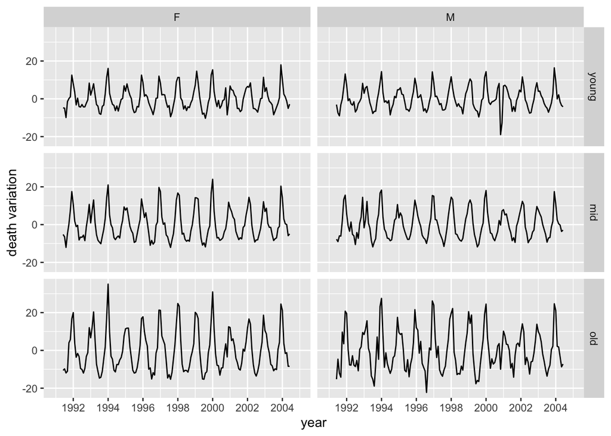

```r
deathsage %>%
  ggplot(aes(index, variation)) +
  geom_line()+
  ylab("death variation")+
  xlab("year")+
  scale_x_continuous(breaks = seq(1992,2004,2))+
  facet_grid(rows=vars(age_index),cols=vars(sex))
```

Recalculating the measure of magnitude of variation:

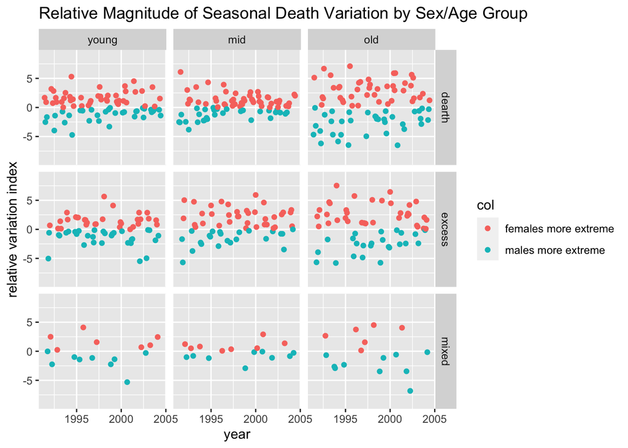

```r
deaths4 <- merge(deaths2,deaths3,by=c("index","age_index"))
deaths4 <- deaths4 %>%
  select(c(index,age_index,sex.x,variation.x,sex.y,variation.y)) %>%
  filter(!is.na(variation.x))

deaths4$diff <- abs(deaths4$variation.x)-abs(deaths4$variation.y)
deaths4$col <- ifelse(deaths4$diff >0,"females more extreme","males more extreme")
deaths4$type <- ifelse(deaths4$variation.x >0 & deaths4$variation.y > 0,"excess",NA)
deaths4$type <- ifelse(deaths4$variation.x <0 & deaths4$variation.y < 0,"dearth",deaths4$type)
deaths4$type <- ifelse(is.na(deaths4$type),"mixed",deaths4$type)


deaths4 %>%
  ggplot(aes(index, diff,color=col)) +
  geom_point()+
  ylab("relative variation index")+
  xlab("year")+
  facet_grid(rows=vars(type),cols=vars(age_index))+
  ylim(c(-9,9))+
  ggtitle("Relative Magnitude of Seasonal Death Variation by Sex/Age Group")
```

The difference here is not so clear! It looks like for the middle-old, women tend to have more seasonal variation, but the young-old and oldest old look much more even between the two sexes. This is in line with the hypothesis that the age distribution of deaths drove a good portion of the sex difference in seasonality we observed above in aggregate. Let's look at this as a table.

```r
table <- as.data.frame(table(deaths4$col,deaths4$type,deaths4$age_index))
colnames(table) <- c("Sex","Direction of Variation","Age Group","Count")
levels(table$Sex) <- c("Females","Males")
table <- table %>%
  #filter(`Direction of Variation` != "mixed") %>%
  spread(`Sex`,Count)%>%
  mutate(Percentage=round(Females/(Females + Males)*100,1))%>%
  select(-c(Females,Males)) %>%
  spread(`Age Group`,Percentage)

colnames(table) <- c("Direction of Variation","Youngest old","Middle old","Oldest old")
levels(table$`Direction of Variation`) <- c("Lower-than-average deaths","Higher-than-average deaths","Mixed")

table %>%
  kable() %>%
  kable_styling() %>%
  add_header_above(c(" " = 1, "Percent of the time women have higher variation than men" = 3))
```

| Direction of Variation | Percent of the time women have higher variation than men Youngest old | Percent of the time women have higher variation than men Middle old | Percent of the time women have higher variation than men Oldest old |
| --- | --- | --- | --- |
| Lower-than-average deaths | 55.7 | 63.0 | 53.8 |
| Higher-than-average deaths | 50.0 | 61.0 | 59.0 |
| Mixed | 43.8 | 47.1 | 37.5 |

From the table we can see that, within these age groups, women do tend to have more variance in death counts than men. The exception is in months where one sex has higher-than-average deaths and the other has lower-than-average deaths; in this case, men tend to be farther from the average than women.

The three-level age group breakdown does not entirely remove age structure effects from our analysis - indeed, we might posit that, for example, the significantly higher variation in death count among women in the middle-old age group is because this group skews older among women than among men.

# Seasonal death heatmaps by age group

Finally, we can repeat our heatmaps:

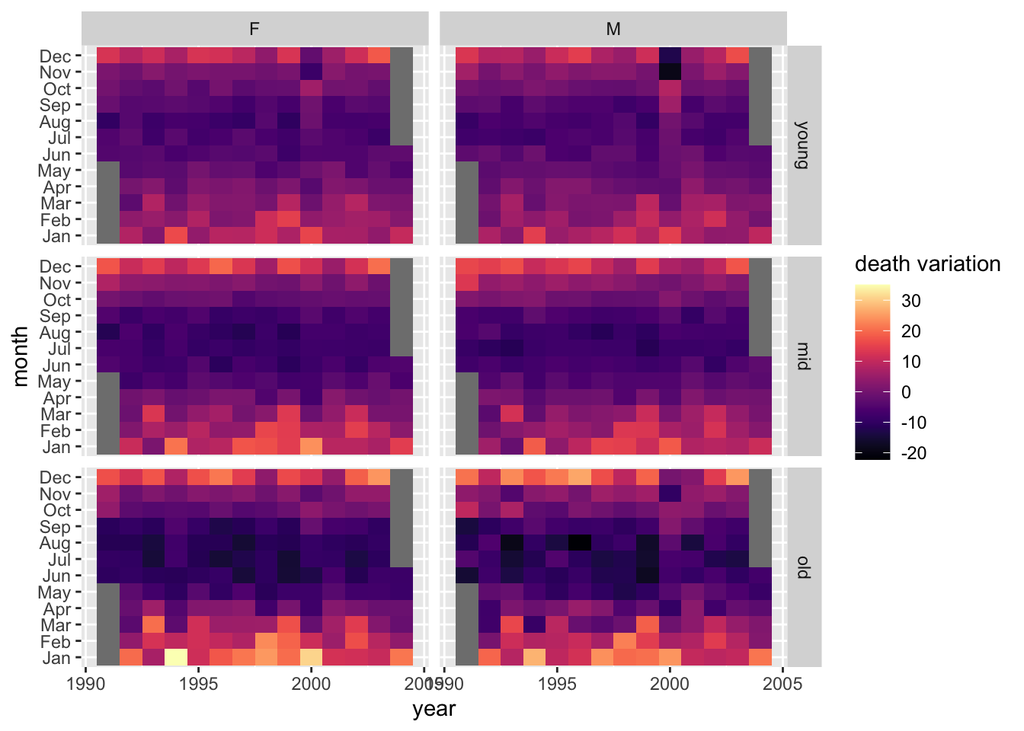

```r
deathsage$dmonth_text <- as.factor(deathsage$dmonth)

levels(deathsage$dmonth_text) <- c("Jan","Feb","Mar","Apr","May","Jun","Jul","Aug","Sep","Oct","Nov","Dec")

ggplot(deathsage, aes(dyear, dmonth_text, fill= variation)) +
  geom_tile() +
  scale_fill_viridis(option = "magma")+
  ylab("month")+
  xlab("year")+
  scale_color_discrete(name="death variation")+
  labs(fill = "death variation")+
  facet_grid(rows=vars(age_index),cols=vars(sex))
```

# Conclusion

However, this exercise on its own probably does not add much to our knowledge of seasonal mortality trends, which are heavily driven by influenza and pneumonia mortality and are thus pretty well-studied using datasets that include cause-of-death data. The potential added value from this data is in the many individual-level covariates available to us in the 1940 census. A future vignette will explore how to extend this analysis beyond the descriptive, by linking the full Numident data to the 1940 census.

# Epilogue

Although this vignette focused on seasonal variation, we can also use the yearly deaths data we generated to isolate the time trend, without the seasonal variation:

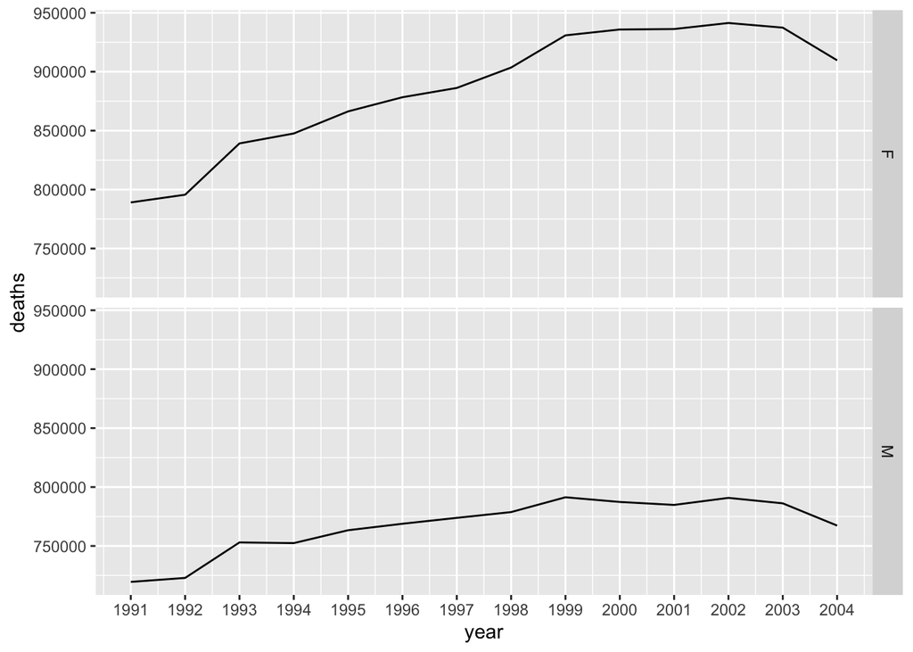

```r
yrdeaths %>%
  ggplot(aes(dyear, deaths)) +
  geom_line()+
  ylab("deaths")+
  xlab("year")+
  scale_x_continuous(breaks = seq(1991, 2004, 1),lim=c(1991,2004))+
  facet_grid(rows=vars(sex))
```

Wow! Looks like female deaths rose a lot more than male deaths during this period. Remember that these are raw counts, not rates, so changes in the population size and structure will have a large effect. To be on the safe side, let's compare this data to HMD data.

HMD data can be downloaded by creating a free account at [the HMD](https://www.mortality.org). This comparison uses the file "Deaths_lexis.txt," found [here](https://www.mortality.org/hmd/USA/STATS/Deaths_lexis.txt).

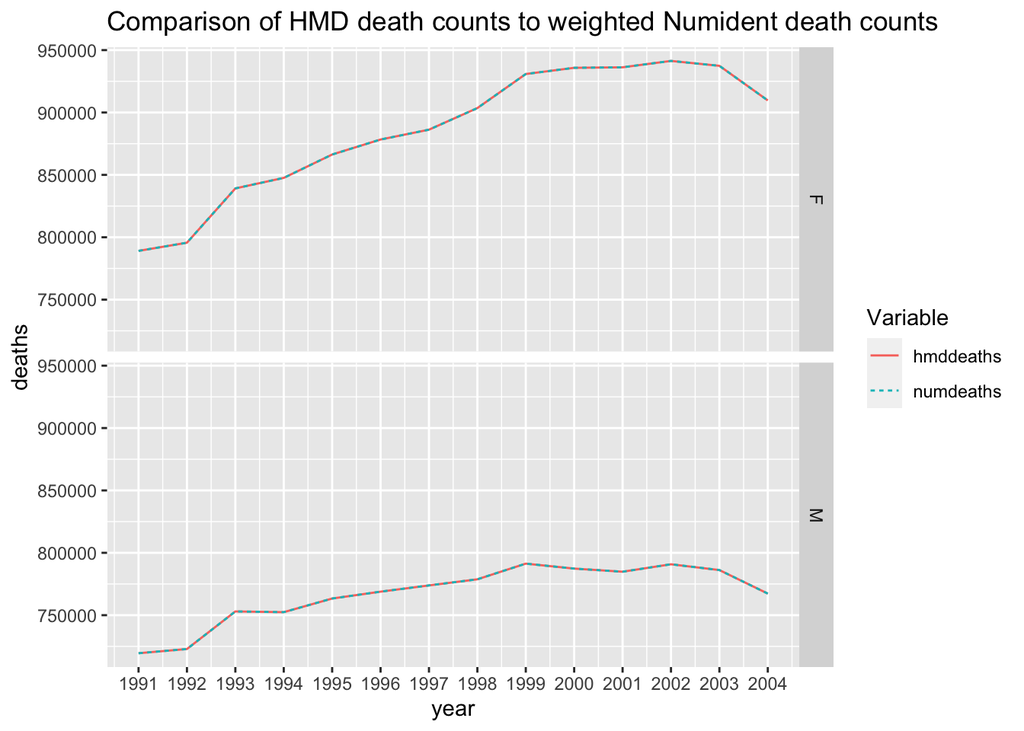

```r
hmd <- read.table("~/CenSoc/data/Deaths_lexis.txt",header=T,skip=2) %>%
  filter(Year %in% c(1991:2004)) %>%
  mutate(Age =ifelse(Age=="110+",110,Age)) %>%
  mutate(Age = as.numeric(as.character(Age))) %>%
  rename(dyear=Year) %>%
  filter(Age %in% (65:95)) %>%
  gather(sex,deaths,c("Female","Male","Total")) %>%
  filter(sex %in% c("Female","Male")) %>%
  mutate(sex = ifelse(sex=="Female","F","M")) %>%
  group_by(dyear,sex) %>%
  summarize(deaths=sum(deaths))

yrdeathslong <- merge(yrdeaths,hmd,by=c("dyear","sex")) %>%
  rename(numdeaths=deaths.x) %>%
  rename(hmddeaths=deaths.y) %>%
  gather(Variable,Value,c("numdeaths","hmddeaths"))


yrdeathslong %>%
  ggplot(aes(dyear, Value,color=Variable)) +
  geom_line(aes(linetype=Variable))+
  ylab("deaths")+
  xlab("year")+
  facet_grid(rows=vars(sex))+
  scale_x_continuous(breaks = seq(1991, 2004, 1),lim=c(1991,2004))+
  ggtitle("Comparison of HMD death counts to weighted Numident death counts")
```

Great! They are identical!